# Expectativas de los cachimbos UTEC 2021-l para afrontar las asignaturas de ciencias del primer ciclo

================================================================================================

### Problemática

Las expectativas al llegar a la universidad son diferentes en cada estudiante. Depende básicamente del contenido trabajado en secundaria y la dificultad o contenidos de los cursos de la universidad.

================================================================================================

### Objetivo

Conocer las expectativas de los ingresantes a Utec en el periodo 2021-1 acerca del rendimiento que podrían tener en los cursos de ciencias del primer ciclo, teniendo en cuenta los conocimientos obtenidos previamente.

================================================================================================

### Preguntas Generales del Proyecto

1. ¿Estudian más los alumnos al ingresar a la universidad Utec?
2. ¿Qué tan preparados se sienten los cachimbos para los cursos del primer ciclo?

================================================================================================

### Recolección de Datos

Los datos se obtuvieron de una encuesta dirigida a los cachimbos de UTEC del periodo 2021-l. Para desarrollar la encuesta nos basamos en los sílabos de las asignaturas Cálculo de una variable, Introducción a la Mecánica y Química General.

================================================================================================

### Unidad muestral

Cualquier alumno ingresante de Utec en el periodo 2021-1.

================================================================================================

### Tamaño de la muestra

Se trabajó con 153 observaciones.

================================================================================================

### Tipo de muestreo

Muestreo por conveniencia: Presentamos un fácil acceso a la unidad de muestreo, mediante el envío de correos a los ingresantes a la universidad.

================================================================================================

```r
library(readr)
library(dplyr)
library(PASWR)
DF <- read_csv("DF_ConocimientosPrev.csv")
```

================================================================================================

Seleccionamos una lista de 8 cursos que consideramos relevante que los alumnos lleven por separado en secundaria para tratar los temas con mayor detalle. En la siguiente gráfica se muestra la cantidad de alumnos que llevó el curso (gris) y la cantidad de alumnos que no (púrpura).

```r
Mtx <- as.matrix(data.frame('Álgebra'=c(sum(!is.na(DF$Álgebra)), nrow(DF)-sum(!is.na(DF$Álgebra))),'Aritmética'=c(sum(!is.na(DF$Aritmética)),nrow(DF)-sum(!is.na(DF$Álgebra))),'Geometría'=c(sum(!is.na(DF$Geometría)),nrow(DF)-sum(!is.na(DF$Geometría))),'Trigonometría'=c(sum(!is.na(DF$Trigonometría)),nrow(DF)-sum(!is.na(DF$Trigonometría))),'Física'=c(sum(!is.na(DF$Física)), nrow(DF)-sum(!is.na(DF$Física))),'Química'=c(sum(!is.na(DF$Química)),nrow(DF)-sum(!is.na(DF$Química))),'Computación'=c(sum(!is.na(DF$Computación)),nrow(DF)-sum(!is.na(DF$Computación))),'Programación'=c(sum(!is.na(DF$Programación)),nrow(DF)-sum(!is.na(DF$Programación)))))
```

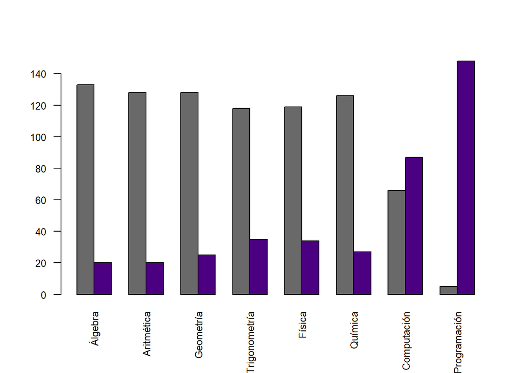

```r
barplot(Mtx, cex.names=0.8, cex.axis=0.8, las=2, col = c("#696969","#4B0082"), beside=TRUE)
```

Observamos que en los cursos del área de matemática y ciencias, la gran mayoría de alumnos llevó los cursos. Sin embargo, para computación y programación ocurre lo contrario. Por ello, pensamos que los alumnos tendrán mayor dificultad en la asignatura Programación 1, ya que lo verán por primera vez.

================================================================================================

### Aumento en el tiempo de estudio fuera de clases de los cachimbos

Le preguntamos a los cachimbos cuántas horas semanales estudiaron fuera de clases durante el último año de secundaria y durante las primeras semanas del presente semestre.

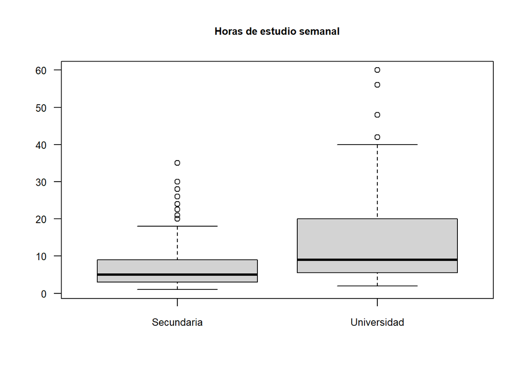

```r
boxplot(DF$HorasSec, DF$HorasUtec, main = "Horas de estudio semanal", cex.main=0.8, cex.axis=0.8, names=c("Secundaria","Universidad"), las=1)
```

Comparando los boxplot parece duplicarse el rango, la mediana y el rango intercuartil. De ahí surge la siguiente hipótesis.

#### Validamos la hipótesis de que cada alumno duplicó sus horas de estudio semanales.

Se aplica una prueba bilateral a la razón de entre las horas de estudio en secundaria y en Utec. Como no se conoce la desviación estándar poblacional, utilizamos la cuasidesviación típica.

```r
z.test(DF$HorasUtec/DF$HorasSec, mu = 2, sigma.x = sd(DF$HorasUtec/DF$HorasSec))
```

```
##
##  One Sample z-test
##
## data:  DF$HorasUtec/DF$HorasSec
## z = 1.7764, p-value = 0.07567
## alternative hypothesis: true mean is not equal to 2
## 95 percent confidence interval:
##  1.957502 2.865078
## sample estimates:
## mean of x
##   2.41129
```

*Observaciones*

- p-valor
  - El test devuelve un p-valor de 0.07567. Ya que es superior a la significancia de 0.05, no se rechaza la H0 (μ = 2). Así, es sensato pensar que los cachimbos duplicaron sus horas de estudio al ingresar a la universidad.
- Intervalo de Confianza
  - Encontramos el intervalo (1.95 , 2.87) a un nivel de confianza de 95% para la razon entre las horas de estudio semanales durante las primeras semanas del ciclo 2021-1 y el último año de secundaria de los cachimbos.

================================================================================================

#### Validamos la hipótesis de que la media poblacional de las horas de estudio fuera de clase durante 5to de secundaria y las primeras semanas del ciclo 2021-1 son 7 y 14

```r
z.test(DF$HorasSec, mu = 7, sigma.x = sd(DF$HorasSec))
```

```
##
##  One Sample z-test
##
## data:  DF$HorasSec
## z = 0.83775, p-value = 0.4022
## alternative hypothesis: true mean is not equal to 7
## 95 percent confidence interval:
##  6.338974 8.647954
## sample estimates:
## mean of x
##  7.493464
```

```r
z.test(DF$HorasUtec, mu = 14, sigma.x = sd(DF$HorasUtec))
```

```
##
##  One Sample z-test
##
## data:  DF$HorasUtec
## z = -0.79728, p-value = 0.4253
## alternative hypothesis: true mean is not equal to 14
## 95 percent confidence interval:
##  11.45712 15.07229
## sample estimates:
## mean of x
##  13.26471
```

*Observaciones*

- Se tomó la misma consideración de emplear la cuasidesviación típica al desconocer la desviación típica poblacional.
- En ambos casos, no se rechaza la H0 ya que los valores conjeturados para las medias poblacionales caen dentro del intervalo de confianza.
- Los p-values 0.4022 y 0.4253 son similares y muy superiores a la significancia de 0.05.

================================================================================================

### Autopercepción de los cachimbos sobre el manejo de tópicos básicos para la asignaturas de primer ciclo

Se realizó tres preguntas donde cada estudiante seleccionó en un rango del 1 al 5 qué tan preparado se siente para comprender los temas de la asignatura en función de sus conocimientos previos.

Se definió la variable “cálculo”, “química” e “intromecánica” que guardan la suma de los valores seleccionados en cada pregunta. Por ende, sus valores estarán dentro del rango de 3 a 15.

```r
cálculo <- c(DF$CálculoP1 + DF$CálculoP2 + DF$CálculoP3)
química <- c(DF$QuímicaP1 + DF$QuímicaP2 + DF$QuímicaP3)
intromecánica <- c(DF$IntroMecánicaP1 + DF$IntroMecánicaP2 + DF$IntroMecánicaP3)
```

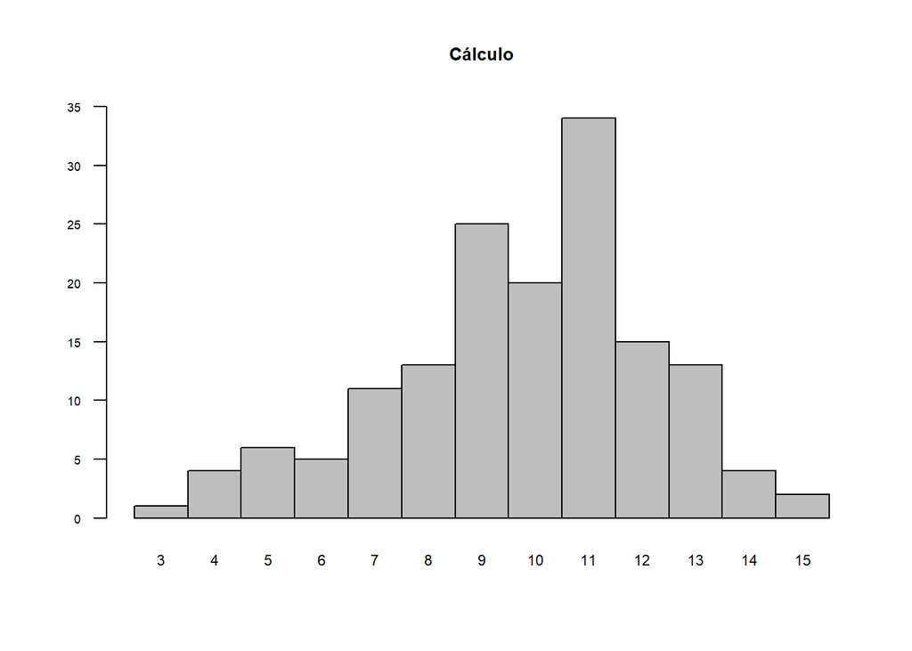

```r
barplot(table(cálculo), main = "Cálculo", cex.names = 0.7, cex.axis = 0.55, space=0, ylim = c(0,35), cex.main = 0.8, las=1)
```

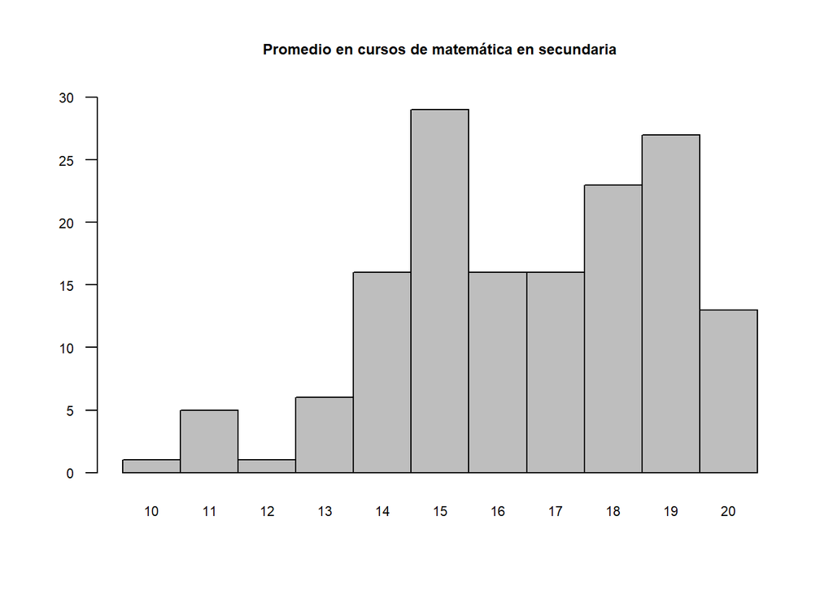

```r
barplot(table(DF$PromMate), main = "Promedio en cursos de matemática en secundaria", ylim=c(0,30), space=0, cex.main=0.75, cex.names=0.7, cex.axis=0.7, las=1)
```

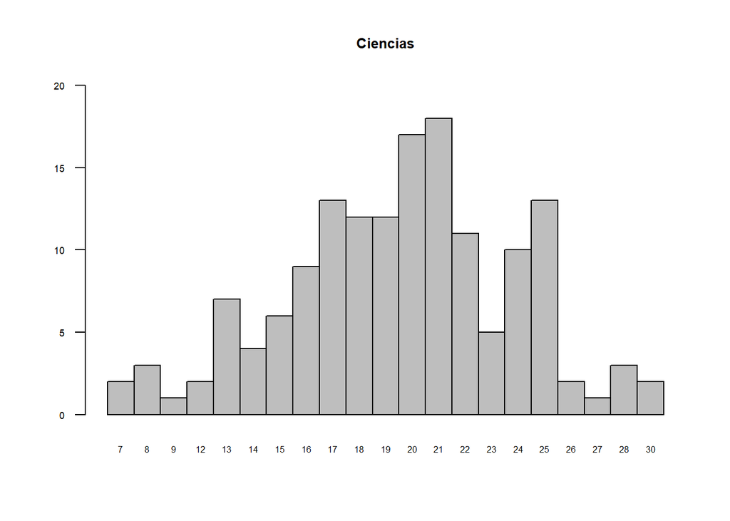

```r
barplot(table(química+intromecánica), main = "Ciencias", cex.names = 0.5, cex.axis = 0.55, space=0, ylim = c(0,20), cex.main = 0.8, las=1)
```

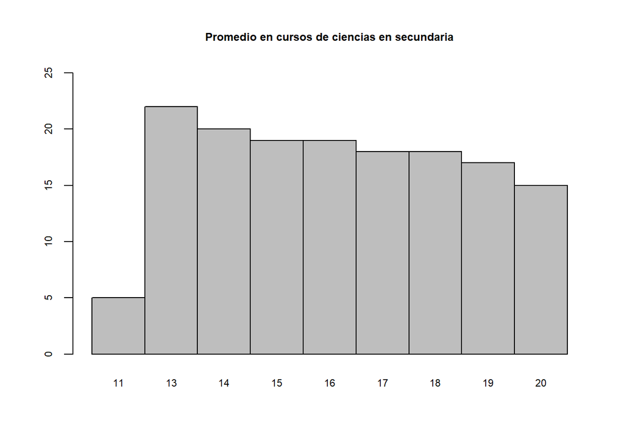

```r
barplot(table(DF$PromCiencias), main = "Promedio en cursos de ciencias en secundaria", ylim=c(0,25), space=0, cex.main=0.75, cex.names=0.7, cex.axis=0.7)
```

================================================================================================

Planteamos la hipótesis de que existe una relación lineal entre el promedio obtenido en secundaria y la autopercepción del alumno sobre la comprensión de los tópicos de la asignatura.

*Resumen de la Regresión Lineal*

```r
modelo_lineal_1 <- lm(cálculo~DF$PromMate)
summary(modelo_lineal_1)
```

```
##
## Call:
## lm(formula = cálculo ~ DF$PromMate)
##
## Residuals:
##     Min      1Q  Median      3Q     Max
## -6.2266 -1.4788  0.5212  1.7082  5.1473
##
## Coefficients:
##             Estimate Std. Error t value Pr(>|t|)
## (Intercept)  6.67456    1.39533   4.783 4.06e-06 ***
## DF$PromMate  0.18695    0.08358   2.237   0.0268 *
## ---
## Signif. codes:  0 '***' 0.001 '**' 0.01 '*' 0.05 '.' 0.1 ' ' 1
##
## Residual standard error: 2.423 on 151 degrees of freedom
## Multiple R-squared:  0.03207,    Adjusted R-squared:  0.02566
## F-statistic: 5.003 on 1 and 151 DF,  p-value: 0.02677
```

```r
modelo_lineal_2 <- lm(química+intromecánica~DF$PromCiencias)
summary(modelo_lineal_2)
```

```
##
## Call:
## lm(formula = química + intromecánica ~ DF$PromCiencias)
##
## Residuals:
##      Min       1Q   Median       3Q      Max
## -12.9671  -2.3374   0.2059   3.0329  11.1194
##
## Coefficients:
##                 Estimate Std. Error t value Pr(>|t|)
## (Intercept)      10.7319     2.3212   4.623 8.05e-06 ***
## DF$PromCiencias   0.5433     0.1426   3.810 0.000202 ***
## ---
## Signif. codes:  0 '***' 0.001 '**' 0.01 '*' 0.05 '.' 0.1 ' ' 1
##
## Residual standard error: 4.286 on 151 degrees of freedom
## Multiple R-squared:  0.08771,    Adjusted R-squared:  0.08167
## F-statistic: 14.52 on 1 and 151 DF,  p-value: 0.0002016
```

================================================================================================

### Conclusiones

- Se validan las hipótesis de que la media poblacional de las horas de estudio semanal durante el último año de secundaria y las primeras semanas del ciclo son 7 y 14, respectivamente. Además, se valida la hipótesis de que cada alumno duplicó sus horas de estudio semanal.
- Por lo tanto, tiene sentido decir que los cachimbos tienen altas expectativas sobre el nivel académico de Utec, puesto que han duplicado rápidamente su ritmo de estudio.
- En contraposición a nuestra hipótesis, encontramos que no es fiable predecir la autopercepción de los alumnos sobre el posible desempeño en la universidad tomando como insumo únicamente sus notas en 5to de secundaria.
- Esto podría explicarse en que los colegios públicos y privados del Perú imparten sus clases bajo currículas escolares muy variadas, tanto en contenido como en exigencia.